# Data Wrangling with R

Author

Allen Cosme

Published

March 18, 2026

**Note**

**note**: this codebook will follow the structure and content of the published codebook of [M05-1-Data wrangling with Tidyvverse in R](https://jmjung.quarto.pub/m05-1-principles-data-wrangling-with-tidyverse-in-r/) by Jae Jung, Ph.D.

# 1 Overview

## 1.1 Learning outcome

> By the end of this module, you should be able to:
- Describe the concept of Data Wrangling.
- Describe how Tibbles are different from data frames
- Explain how to convert wide or long data to “Tidy” data
- Explain how to merge relational data sets using join functions.
- Explain how to use grouped mutates and filter together.
- Be familiar with major dplyr functions for transforming data.
- Create a new variable with `mutate()` and `case_when()`.
- Use the pipe operator to shape the data to prepare for analysis and visualization

## 1.2 Textbook chapters covered

- Ch3: Data Transformation
- Ch5: Data Tidying
- Ch13: Numbers

# 2 Introduction to data wrangling

## 2.1 loading packages

```r
library(tidyverse)
```

# 3 what is Tidyverse

The tidyverse is a collection of R packages that share a common design philosophy and are designed to work together seamlessly. The tidyverse includes packages for data manipulation, visualization, and modeling, among other tasks.

> Some of the core packages in the tidyverse include:
- ggplot2: for data visualization
- dplyr: for data manipulation
- tidyr: for data tidying
- readr: for data import
- purrr: for functional programming
- tibble: for data frames
- stringr: for string manipulation
- forcats: for working with categorical variables

## 3.1 intitial data prep and exploration

```r
#install.packages("nycflights13")
library(nycflights13)
data()
```

# 4 data wrangling with dplyr

**Note**

For MacOS, use `shift + option + I` for multi cursor activation

Data sets in package ‘nycflights13’:

- airlines Airline names.
- airports Airport metadata
- flights Flights data
- planes Plane metadata.
- weather Hourly weather data

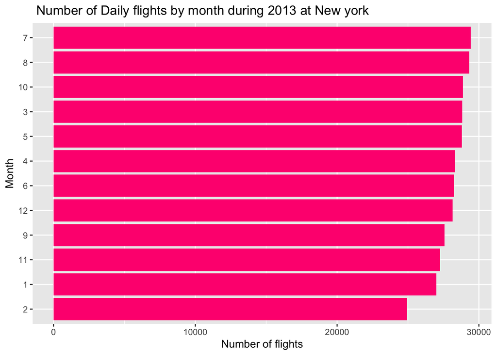

```r
flights <- flights

flights |>
  count(year, month) |>
  arrange(desc(n)) |>
  mutate(month = as_factor(month)) |>
  mutate(month = fct_reorder(month,n)) |>
  ggplot(aes(month, n, fill = year)) +
  geom_col(fill = "#FF007F", show.legend = FALSE) +
  coord_flip() +
  labs(x = "Month",
      y = "Number of flights",
      title = " Number of Daily flights by month during 2013 at New york"
      )
```